# 爬虫运维数据统计 - HTML报告

- 运维数据总览
- 各岗位数据总览
- 爬虫运维分析条形图
- 爬虫运维生命周期总览

## 运维数据总览

- **运维(历史入库完成)**: 已入库爬虫中, 被运维发现异常的次数
- **废弃(历史入库完成)**: 已入库爬虫中，内运维废弃的爬虫数量
- **abnormal_times**: 爬虫运维发现异常的次数
- **total_times**: 爬虫运维总次数
- **pre**: 运维发现异常比率

```python
from base_tools import *
init('诚信数据', '2019.1', version=1)
life_table = get_spider_life_table()
```

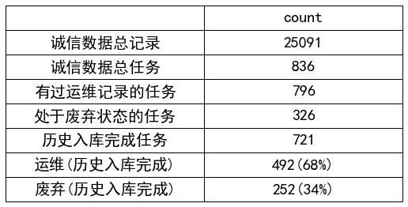

|  | abnormal_times | total_times | pre |
| --- | --- | --- | --- |
| count | 432.000000 | 432.000000 | NaN |
| mean | 2.708333 | 9.708333 | 27% |
| std | 1.915409 | 3.753807 | NaN |
| min | 1.000000 | 2.000000 | NaN |
| 50% | 2.000000 | 9.000000 | NaN |
| max | 15.000000 | 19.000000 | NaN |

```python
draw_table()
```

## 各岗位数据总览

- **数据来源: 已废弃爬虫. 已废弃爬虫, 具有完整的生命周期, 有一定代表性, 故以此进行分析**
- **index中的count, 表示已废弃爬虫数据总量.**
- **mean表示任意爬虫中, 各岗位对爬虫的平均操作次数**

```python
get_each_work_states()
```

|  | 需求岗 | 开发岗 | 清洗岗 | 测试岗 | 入库岗 | 运维岗 |
| --- | --- | --- | --- | --- | --- | --- |
| count | 252 | 252 | 252 | 252 | 252 | 252 |
| mean | 0.365079 | 12.996 | 6.03968 | 11.6151 | 3.09921 | 3.34127 |
| std | 0.657209 | 6.9926 | 4.11566 | 8.07082 | 1.52864 | 1.42355 |
| min | 0 | 2 | 1 | 1 | 1 | 1 |
| 50% | 0 | 11 | 5 | 9 | 3 | 3 |
| max | 4 | 38 | 21 | 46 | 8 | 9 |

## 爬虫运维分析条形图

- 条形图中红黑各表示**运维发现异常的爬虫**和**运维时废弃的爬虫**的统计及占据当月运维总次数的百分比
- **废弃比率**: 在目标周期中，平均每月**运维时废弃爬虫**的比率
- **异常比率**: 在目标周期中，平均每月**运维时发现异常爬虫**的比率

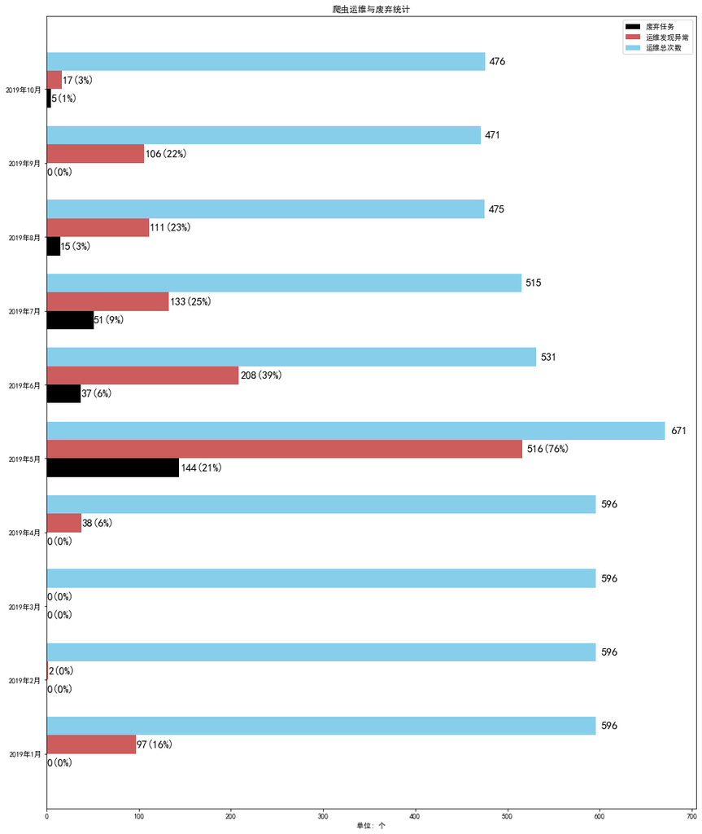

|  | 需求岗 | 开发岗 | 清洗岗 | 测试岗 | 入库岗 | 运维岗 | 废弃任务 | 运维发现异常 | 运维总次数 | 废弃比率 | 异常比率 |
| --- | --- | --- | --- | --- | --- | --- | --- | --- | --- | --- | --- |
| count | 176 | 176 | 176 | 176 | 176 | 176 | 10.000000 | 10.000 | 10.00000 | NaN | NaN |
| mean | 0.352273 | 11.7216 | 5.47727 | 10.5 | 2.55114 | 3.09091 | 25.200000 | 122.800 | 552.30000 | 4% | 22% |
| std | 0.701668 | 6.54887 | 3.70321 | 7.59172 | 1.12514 | 1.22485 | 45.467449 | 153.157 | 68.29682 | NaN | NaN |
| min | 0 | 2 | 1 | 1 | 1 | 1 | 0.000000 | 0.000 | 471.00000 | NaN | NaN |
| 50% | 0 | 10 | 4 | 8.5 | 2 | 3 | 2.500000 | 101.500 | 563.50000 | NaN | NaN |
| max | 4 | 38 | 21 | 46 | 7 | 8 | 144.000000 | 516.000 | 671.00000 | NaN | NaN |

```python
draw_bar_pic()
```

## 爬虫运维生命周期总览

- 数据来源: 生命周期在目标周期内的所有**有过运维异常记录**的爬虫. 帮助定位异常爬虫.
- **start_time**: 爬虫第一次入库完成时间, 进入运维期
- **first_time**: 爬虫第一次运维发现异常的时间
- **last_time**: 爬虫最后一次运维发现异常的时间
- **abnormal_times**: 运维发现异常的总次数
- **total_times**: 运维总次数
- **is_live**: 爬虫是否还存活, 即未被废弃

```python
life_table
```

|  | start_time | first_time | last_time | abnormal_times | total_times | is_live |
| --- | --- | --- | --- | --- | --- | --- |
| 行政处罚-海淀 | 2018年3月 | 2019年6月 | 2019年6月 | 1.0 | 18.0 | True |
| 行政处罚-汕头 | 2018年10月 | 2019年7月 | 2019年7月 | 4.0 | 12.0 | True |
| 行政处罚-荣成 | 2018年8月 | 2019年6月 | 2019年6月 | 5.0 | 10.0 | False |
| 行政处罚-乌海 | 2018年8月 | 2019年6月 | 2019年6月 | 3.0 | 10.0 | False |
| 行政处罚-芜湖 | 2018年8月 | 2019年5月 | 2019年5月 | 4.0 | 13.0 | True |
| 行政处罚-宿迁 | 2018年3月 | 2019年7月 | 2019年7月 | 5.0 | 18.0 | True |
| 行政处罚-广东 | 2018年8月 | 2019年6月 | 2019年6月 | 3.0 | 14.0 | True |
| 行政处罚-广州 | 2018年8月 | 2019年7月 | 2019年7月 | 1.0 | 14.0 | True |
| 行政处罚-重庆 | 2018年8月 | 2019年6月 | 2019年6月 | 2.0 | 14.0 | True |
| 行政处罚-青海 | 2018年8月 | 2019年7月 | 2019年7月 | 3.0 | 10.0 | False |
| 行政处罚-甘肃 | 2019年5月 | 2019年6月 | 2019年6月 | 1.0 | 5.0 | True |
| 黑名单-甘肃 | 2018年8月 | 2019年6月 | 2019年6月 | 1.0 | 14.0 | True |
| 行政处罚-青岛 | 2018年3月 | 2019年8月 | 2019年8月 | 3.0 | 16.0 | False |
| 黑名单-宁夏 | 2018年9月 | 2019年5月 | 2019年5月 | 3.0 | 7.0 | False |
| 黑名单-大连 | 2018年9月 | 2019年5月 | 2019年5月 | 2.0 | 13.0 | True |
| 黑名单-兵团 | 2018年9月 | 2019年8月 | 2019年8月 | 3.0 | 13.0 | True |
| 黑名单-南阳 | 2018年9月 | 2019年8月 | 2019年8月 | 3.0 | 13.0 | True |
| 行政处罚-广西 | 2018年8月 | 2019年5月 | 2019年5月 | 5.0 | 8.0 | False |
| 黑名单-陕西 | 2019年1月 | 2019年6月 | 2019年6月 | 3.0 | 4.0 | False |
| 黑名单-重庆 | 2018年8月 | 2019年6月 | 2019年6月 | 7.0 | 13.0 | True |
| 黑名单-惠州 | 2018年8月 | 2019年5月 | 2019年5月 | 3.0 | 8.0 | False |
| 黑名单-苏州 | 2018年8月 | 2019年5月 | 2019年5月 | 3.0 | 9.0 | False |
| 黑名单-苏州2 | 2018年8月 | 2019年5月 | 2019年5月 | 3.0 | 9.0 | False |
| 黑名单-中国2 | 2018年8月 | 2019年5月 | 2019年5月 | 1.0 | 14.0 | True |
| 黑名单-宁夏2 | 2018年9月 | 2019年6月 | 2019年6月 | 1.0 | 13.0 | True |
| 黑名单-中国3 | 2018年8月 | 2019年6月 | 2019年6月 | 2.0 | 10.0 | False |
| 黑名单-云南 | 2018年8月 | 2019年8月 | 2019年8月 | 3.0 | 14.0 | True |
| 黑名单-安徽2 | 2018年9月 | 2019年8月 | 2019年8月 | 3.0 | 13.0 | True |
| 黑名单-河北 | 2019年1月 | 2019年5月 | 2019年5月 | 3.0 | 8.0 | True |
| 黑名单-鞍山 | 2018年9月 | 2019年6月 | 2019年6月 | 1.0 | 13.0 | True |
| ... | ... | ... | ... | ... | ... | ... |
| 信用中国黑名单-辽宁 | 2019年1月 | 2019年5月 | 2019年5月 | 2.0 | 3.0 | False |
| 信用中国黑名单-辽阳 | 2019年1月 | 2019年5月 | 2019年5月 | 2.0 | 4.0 | False |
| 住建部-海南企业黑名单 | 2019年1月 | 2019年5月 | 2019年5月 | 3.0 | 3.0 | False |
| 统计失信-河北 | 2019年1月 | 2019年6月 | 2019年6月 | 3.0 | 9.0 | True |
| 国土资源-北京行政处罚结果 | 2019年5月 | 2019年8月 | 2019年8月 | 3.0 | 4.0 | True |
| 国土资源-北京闲置土地信息 | 2019年1月 | 2019年8月 | 2019年8月 | 2.0 | 9.0 | True |
| 财政部-海南-监督管理 | 2019年5月 | 2019年7月 | 2019年7月 | 1.0 | 5.0 | True |
| 信用中国行政处罚-无锡-2019版 | 2019年5月 | 2019年7月 | 2019年7月 | 1.0 | 4.0 | True |
| 信用中国行政处罚-苏州-2019版 | 2019年5月 | 2019年9月 | 2019年9月 | 2.0 | 4.0 | True |
| 安全黑名单-吉林-2019版 | 2019年5月 | 2019年6月 | 2019年6月 | 1.0 | 4.0 | True |
| 质检处罚-山东-2019版 | 2019年5月 | 2019年9月 | 2019年9月 | 2.0 | 4.0 | True |
| 食药监-湖南-2019版 | 2019年5月 | 2019年9月 | 2019年9月 | 1.0 | 4.0 | True |
| 国土资源-上海行政处罚-2019版 | 2019年5月 | 2019年8月 | 2019年8月 | 1.0 | 4.0 | True |
| 重大税收违法-广西-2019版 | 2019年7月 | 2019年9月 | 2019年9月 | 2.0 | 2.0 | True |
| 重大税收违法-宁夏-2019版 | 2019年5月 | 2019年9月 | 2019年9月 | 2.0 | 4.0 | True |
| 重大税收违法-厦门-2019版 | 2019年5月 | 2019年7月 | 2019年7月 | 1.0 | 4.0 | True |
| 重大税收违法-山西-2019版 | 2019年5月 | 2019年9月 | 2019年9月 | 1.0 | 4.0 | True |
| 食药监-宁夏-2019版 | 2019年5月 | 2019年8月 | 2019年8月 | 3.0 | 4.0 | True |
| 信用中国黑名单-苏州-2019版 | 2019年5月 | 2019年7月 | 2019年7月 | 3.0 | 4.0 | True |
| 国土资源-重庆土地执法-2019版 | 2019年5月 | 2019年7月 | 2019年7月 | 4.0 | 4.0 | True |
| 信用中国行政处罚-武汉-2019版 | 2019年6月 | 2019年7月 | 2019年7月 | 2.0 | 4.0 | True |
| 信用中国行政处罚-辽宁-2019版 | 2019年5月 | 2019年9月 | 2019年9月 | 1.0 | 4.0 | True |
| 信用中国黑名单-辽宁-2019版 | 2019年5月 | 2019年9月 | 2019年9月 | 2.0 | 4.0 | True |
| 信用中国黑名单-上海-2019版 | 2019年5月 | 2019年9月 | 2019年9月 | 1.0 | 4.0 | True |
| 住建部-安徽行政处罚-2019版 | 2019年5月 | 2019年7月 | 2019年7月 | 3.0 | 4.0 | True |
| 重大税收违法-新疆国税-2019版 | 2019年5月 | 2019年7月 | 2019年7月 | 3.0 | 4.0 | True |
| 国土资源-广西-执法监察-2019版 | 2019年7月 | 2019年9月 | 2019年9月 | 1.0 | 3.0 | True |
| 信用中国黑名单-呼和浩特-2019版 | 2019年7月 | 2019年9月 | 2019年9月 | 1.0 | 2.0 | True |
| 住建部-青海-2019版 | 2019年8月 | 2019年9月 | 2019年9月 | 2.0 | 2.0 | True |
| 应急管理-上海-2019版 | 2019年7月 | 2019年9月 | 2019年9月 | 1.0 | 2.0 | True |

337 rows × 6 columns

返回顶部  
 运维数据总览  
 各岗位数据总览  
 爬虫运维分析条形图  
 爬虫运维生命周期总览